# Assignment-Python Vietnamese Stock Market Analysis

##### 2. What was the average daily return of each stock? (Tính lợi suất hàng ngày trung bình của mỗi cổ phiếu)

```python
import pandas as pd

# Bước 1: Tải dữ liệu của các cổ phiếu BID, ACB, MBB
loader = dt.DataLoader(
    symbols=["BID", "ACB", "MBB"],  # Danh sách cổ phiếu
    start="2024-01-01",  # Thời gian bắt đầu
    end="2024-11-30",    # Thời gian kết thúc
    minimal=True,
    data_source="cafe"
)

# Tải và xử lý dữ liệu
data = loader.download()
data = data.stack()
data.reset_index(inplace=True)
data.set_index('date', inplace=True)

# Bước 2: Tính toán lợi suất hàng ngày cho từng cổ phiếu
data['daily_return'] = data.groupby('Symbols')['close'].pct_change()

# Bước 3: Tính lợi suất hàng ngày trung bình cho từng cổ phiếu
average_daily_returns = data.groupby('Symbols')['daily_return'].mean()

# Hiển thị kết quả
print("Lợi suất hàng ngày trung bình của từng cổ phiếu:")
print(average_daily_returns * 100)  # Hiển thị dưới dạng %
```

```
[2024-12-21 06:32:24] - Assitant - INFO      - download - line 34 - Start downloading data symbols ['BID', 'ACB', 'MBB'] from CAFEF, start: 01/01/2024, end: 30/11/2024!
[2024-12-21 06:32:24] - Assitant - INFO      - download_one - line 94 - data BID from 2024-01-01 to 2024-11-30 have already cloned!
[2024-12-21 06:32:25] - Assitant - INFO      - download_one - line 94 - data ACB from 2024-01-01 to 2024-11-30 have already cloned!
[2024-12-21 06:32:25] - Assitant - INFO      - download_one - line 94 - data MBB from 2024-01-01 to 2024-11-30 have already cloned!
```

```
Lợi suất hàng ngày trung bình của từng cổ phiếu:
Symbols
ACB    0.000879
BID   -0.025639
MBB   -0.097371
Name: daily_return, dtype: float64
```

##### 3. What are the moving averages of the stocks over different time windows? (Tính toán trung bình động (moving averages) của các cổ phiếu qua các cửa sổ thời gian khác nhau)

```python
# Đảm bảo rằng dữ liệu được sắp xếp theo 'Biểu tượng' và 'ngày' trước khi áp dụng các phép tính
data = data.sort_values(by=['Symbols', 'date'])

# Tính toán EMA với cách xử lý thích hợp của nhóm theo
data['EMA_30'] = data.groupby('Symbols')['close'].transform(
    lambda x: x.ewm(span=30, adjust=False).mean())
data['EMA_60'] = data.groupby('Symbols')['close'].transform(
    lambda x: x.ewm(span=60, adjust=False).mean())
data['EMA_200'] = data.groupby('Symbols')['close'].transform(
    lambda x: x.ewm(span=200, adjust=False).mean())

# Tính toán SMA (Đường trung bình động đơn giản) trong 30, 60 và 200 ngày
data['SMA_30'] = data.groupby('Symbols')['close'].transform(
    lambda x: x.rolling(window=30).mean())
data['SMA_60'] = data.groupby('Symbols')['close'].transform(
    lambda x: x.rolling(window=60).mean())
data['SMA_200'] = data.groupby('Symbols')['close'].transform(
    lambda x: x.rolling(window=200).mean())

# Hiển thị kết quả
print("Trung bình động (SMA và EMA) cho các cổ phiếu:")
print(data[['Symbols', 'SMA_30', 'SMA_60', 'SMA_200',
      'EMA_30', 'EMA_60', 'EMA_200']].tail())
```

```
Trung bình động (SMA và EMA) cho các cổ phiếu:
Attributes Symbols     SMA_30     SMA_60   SMA_200     EMA_30     EMA_60  \
date
2024-11-25     MBB  24.588333  24.730000  23.87150  24.346665  24.454057
2024-11-26     MBB  24.536667  24.717500  23.87725  24.330751  24.442448
2024-11-27     MBB  24.490000  24.712500  23.88250  24.315864  24.431221
2024-11-28     MBB  24.426667  24.713333  23.88500  24.295486  24.417082
2024-11-29     MBB  24.373333  24.715833  23.88500  24.286100  24.408325

Attributes    EMA_200
date
2024-11-25  23.488381
2024-11-26  23.494467
2024-11-27  23.500492
2024-11-28  23.505462
2024-11-29  23.511876
```

##### 4. What is the correlation between the daily returns of the different stocks? (Phân tích mối tương quan giữa lợi suất hàng ngày của các cổ phiếu khác nhau)

```python
# Tính toán lợi suất hàng ngày
data['daily_return'] = data.groupby('Symbols')['close'].pct_change()
```

```python
# Pivot dữ liệu để mỗi cột đại diện cho daily_return của một cổ phiếu
daily_returns_pivot = data.pivot_table(
    values='daily_return', index='date', columns='Symbols')

# Kiểm tra dữ liệu đã pivot
print(daily_returns_pivot.head())
```

```
Symbols          ACB       BID       MBB
date
2024-01-03  0.022495  0.018605  0.015915
2024-01-04  0.012000 -0.003425  0.049608
2024-01-05  0.005929  0.019473  0.019900
2024-01-08 -0.003929  0.042697  0.009756
2024-01-09 -0.013807 -0.007543  0.007246
```

```python
# Tính ma trận tương quan
correlation_matrix = daily_returns_pivot.corr()

# Hiển thị ma trận tương quan
print("Ma trận tương quan giữa các cổ phiếu:")
print(correlation_matrix)
```

```
Ma trận tương quan giữa các cổ phiếu:
Symbols       ACB       BID       MBB
Symbols
ACB      1.000000  0.422060  0.541149
BID      0.422060  1.000000  0.608487
MBB      0.541149  0.608487  1.000000
```

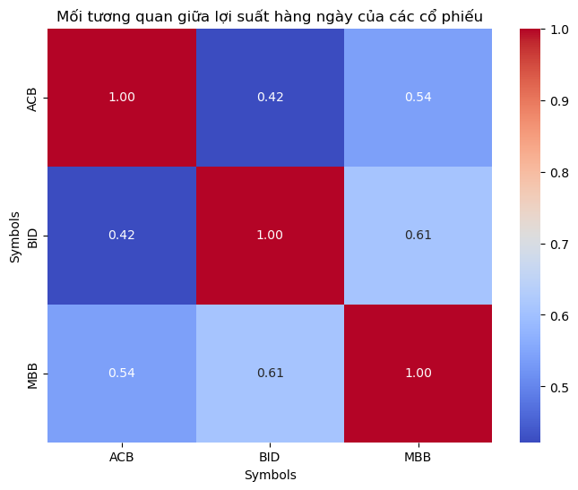

```python
import seaborn as sns
import matplotlib.pyplot as plt

# Vẽ heatmap
plt.figure(figsize=(8, 6))
sns.heatmap(correlation_matrix, annot=True, cmap='coolwarm', fmt=".2f")
plt.title("Mối tương quan giữa lợi suất hàng ngày của các cổ phiếu")
plt.show()
```

##### 5. How much value is at risk (VaR) when investing in a stock? Tính toán giá trị rủi ro (VaR) khi đầu tư vào cổ phiếu

```python
# Lợi suất hàng ngày
data['daily_return'] = data.groupby('Symbols')['close'].pct_change()

# Pivot dữ liệu để dễ tính toán cho từng cổ phiếu
daily_returns_pivot = data.pivot_table(
    values='daily_return', index='date', columns='Symbols')
```

```python
import numpy as np

# Thiết lập độ tin cậy
confidence_level = 5  # VaR ở mức 95% --> 5% phía dưới

# Tính VaR cho từng cổ phiếu
VaR = daily_returns_pivot.apply(
    lambda x: -np.percentile(x.dropna(), confidence_level), axis=0)

# Hiển thị kết quả
print("Giá trị rủi ro (VaR) ở mức độ tin cậy 95% cho từng cổ phiếu:")
print(VaR)
```

```
Giá trị rủi ro (VaR) ở mức độ tin cậy 95% cho từng cổ phiếu:
Symbols
ACB    0.016276
BID    0.018022
MBB    0.021301
dtype: float64
```

```python
confidence_level_99 = 1  # VaR ở mức 99% --> 1% phía dưới

VaR_99 = daily_returns_pivot.apply(
    lambda x: -np.percentile(x.dropna(), confidence_level_99), axis=0)

print("Giá trị rủi ro (VaR) ở mức độ tin cậy 99% cho từng cổ phiếu:")
print(VaR_99)
```

```
Giá trị rủi ro (VaR) ở mức độ tin cậy 99% cho từng cổ phiếu:
Symbols
ACB    0.031052
BID    0.039810
MBB    0.039614
dtype: float64
```

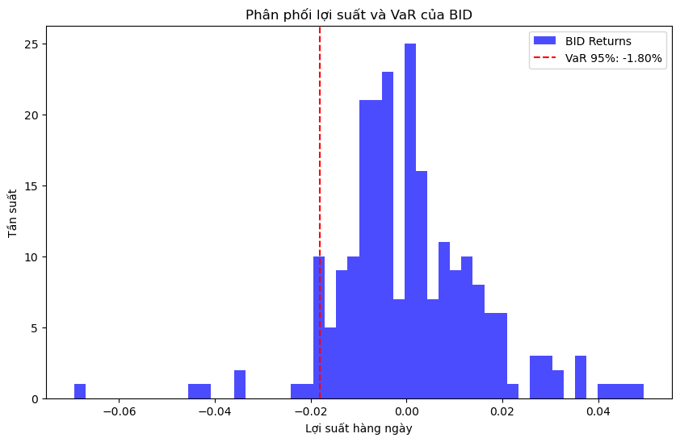

```python
import matplotlib.pyplot as plt

# Chọn cổ phiếu cụ thể để minh họa, ví dụ: BID
stock = 'BID'
returns = daily_returns_pivot[stock].dropna()

# Vẽ histogram
plt.figure(figsize=(10, 6))
plt.hist(returns, bins=50, color='blue', alpha=0.7, label=f'{stock} Returns')

# Đánh dấu VaR
VaR_95 = -np.percentile(returns, 5)
plt.axvline(x=-VaR_95, color='red', linestyle='--',
            label=f'VaR 95%: {-VaR_95:.2%}')

plt.title(f'Phân phối lợi suất và VaR của {stock}')
plt.xlabel('Lợi suất hàng ngày')
plt.ylabel('Tần suất')
plt.legend()
plt.show()
```

   +Tương tự, nhưng với mức độ tin cậy cao hơn (chỉ 1% xác suất thua lỗ vượt mức này).

##### 6. How can we attempt to predict future stock behavior? Dự đoán hành vi cổ phiếu trong tương lai

```python
# Bước 1: Chuẩn bị dữ liệu

# Tính các chỉ số kỹ thuật (ví dụ: Moving Average)
data['MA_10'] = data.groupby('Symbols')['close'].rolling(
    window=10).mean().reset_index(0, drop=True)
data['MA_50'] = data.groupby('Symbols')['close'].rolling(
    window=50).mean().reset_index(0, drop=True)

# Lợi suất hàng ngày đã tính ở bước trước
data['daily_return'] = data.groupby('Symbols')['close'].pct_change()

# Loại bỏ các giá trị NaN
data = data.dropna()

# Kiểm tra dữ liệu
print(data.head())
```

```
Attributes Symbols code   high    low  open  close  adjust  volume_match  \
date
2024-10-22     ACB  ACB  25.85  25.40  25.8  25.40   25.40    12115300.0
2024-10-23     ACB  ACB  25.55  25.15  25.4  25.40   25.40     7700100.0
2024-10-24     ACB  ACB  25.45  25.00  25.4  25.00   25.00     8926700.0
2024-10-25     ACB  ACB  25.10  24.85  25.0  24.90   24.90     9220400.0
2024-10-28     ACB  ACB  25.15  24.75  24.9  25.15   25.15     4995600.0

Attributes   value_match  daily_return     EMA_30     EMA_60    EMA_200  \
date
2024-10-22  3.103540e+11     -0.015504  25.520404  25.226693  25.323524
2024-10-23  1.952040e+11      0.000000  25.512636  25.232375  25.324285
2024-10-24  2.249520e+11     -0.015748  25.479563  25.224756  25.321059
2024-10-25  2.297970e+11     -0.004000  25.442171  25.214108  25.316869
2024-10-28  1.247580e+11      0.010040  25.423322  25.212006  25.315209

Attributes     SMA_30     SMA_60   SMA_200   MA_10   MA_50
date
2024-10-22  25.506667  24.800833  25.88575  25.955  25.007
2024-10-23  25.548333  24.821667  25.89050  25.870  25.039
2024-10-24  25.566667  24.835833  25.89050  25.750  25.067
2024-10-25  25.583333  24.841667  25.88850  25.630  25.094
2024-10-28  25.616667  24.861667  25.88700  25.550  25.127
```

```python
# Bước 2: Chọn mục tiêu dự đoán (target)
data['next_close'] = data.groupby('Symbols')['close'].shift(-1)
data = data.dropna()  # Loại bỏ các hàng không đủ dữ liệu
```

```python
# Bước 3: Chia dữ liệu
from sklearn.model_selection import train_test_split

# Các đặc trưng và mục tiêu
features = ['close', 'volume_match', 'MA_10', 'MA_50', 'daily_return']
target = 'next_close'

X = data[features]
y = data[target]

# Chia dữ liệu
X_train, X_test, y_train, y_test = train_test_split(
    X, y, test_size=0.2, random_state=42)

print("Kích thước tập huấn luyện:", X_train.shape)
print("Kích thước tập kiểm tra:", X_test.shape)
```

```
Kích thước tập huấn luyện: (67, 5)
Kích thước tập kiểm tra: (17, 5)
```

```python
# Bước 4: Áp dụng mô hình dự đoán
from sklearn.ensemble import RandomForestRegressor
from sklearn.metrics import mean_squared_error

# Khởi tạo và huấn luyện mô hình
model = RandomForestRegressor(n_estimators=100, random_state=42)
model.fit(X_train, y_train)

# Dự đoán trên tập kiểm tra
y_pred = model.predict(X_test)

# Đánh giá mô hình
mse = mean_squared_error(y_test, y_pred)
print("MSE trên tập kiểm tra:", mse)
```

```
MSE trên tập kiểm tra: 0.24048308823529355
```

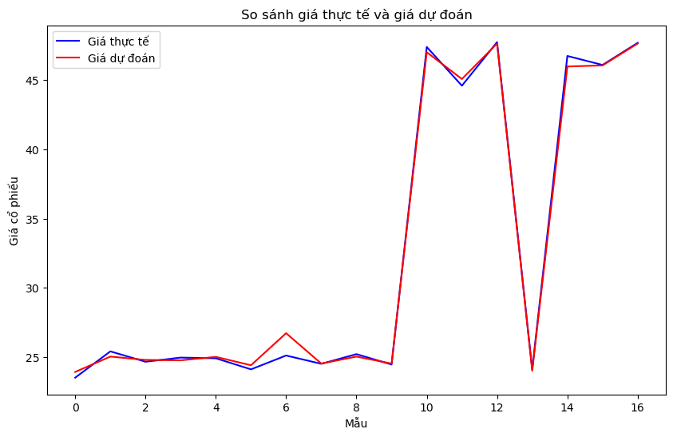

```python
# Bước 5: Trực quan hóa kết quả
import matplotlib.pyplot as plt

plt.figure(figsize=(10, 6))
plt.plot(y_test.values, label="Giá thực tế", color="blue")
plt.plot(y_pred, label="Giá dự đoán", color="red")
plt.title("So sánh giá thực tế và giá dự đoán")
plt.xlabel("Mẫu")
plt.ylabel("Giá cổ phiếu")
plt.legend()
plt.show()
```